# Coding Assignment 2 (Part II)

Fall 2021

```r
library(glmnet)
library(pls)
set.seed(0824) # change the seed to be the last 4-dig of your UIN
```

# Simulation for BostonData2.csv

## Data Preparation

The dataset `BostonData2.csv` contains first 14 columns transformed from Boston Housing data with `Y` being the response variable. 78 extra predictors are added, which are the quadratic terms of the 12 numerical predictors (excluding the binary predictor chas) and all pairwise interactions between the 12 numerical predictors.

```r
bostonData2 = read.csv("BostonData2.csv")
```

```r
head(bostonData2)
```

|  | X | Y | crim | zn | indus | chas | nox | rm | age | dis | rad | tax | ptratio | black | lstat | crim_2 | zn_2 | indus_2 | nox_2 | rm_2 | age_2 | dis_2 | rad_2 | tax_2 | ptratio_2 | black_2 | lstat_2 | crim.zn | crim.indus | … |
| --- | --- | --- | --- | --- | --- | --- | --- | --- | --- | --- | --- | --- | --- | --- | --- | --- | --- | --- | --- | --- | --- | --- | --- | --- | --- | --- | --- | --- | --- | --- |
| 1 | 1 | 3.178054 | -5.064036 | 1.8 | 0.8372475 | 0 | -0.6198967 | 1.883275 | 3.432567 | 1.408545 | 0.0000000 | 5.690359 | 0.4548647 | 3.9690 | 2.231591 | 25.644461 | 3.24 | 0.7009834 | 0.3842719 | 3.546723 | 11.782514 | 1.983999 | 0.000000 | 32.38019 | 0.2069019 | 15.75296 | 4.98 | -9.115265 | -4.239852 | … |
| 2 | 2 | 3.072693 | -3.600502 | 0.0 | 1.9558605 | 0 | -0.7571525 | 1.859574 | 5.529585 | 1.602836 | 0.6931472 | 5.488938 | 1.2364504 | 3.9690 | 3.023243 | 12.963617 | 0.00 | 3.8253902 | 0.5732799 | 3.458015 | 30.576306 | 2.569084 | 0.480453 | 30.12844 | 1.5288097 | 15.75296 | 9.14 | 0.000000 | -7.042080 | … |
| 3 | 3 | 3.546740 | -3.601235 | 0.0 | 1.9558605 | 0 | -0.7571525 | 1.971996 | 2.918119 | 1.602836 | 0.6931472 | 5.488938 | 1.2364504 | 3.9283 | 2.007486 | 12.968893 | 0.00 | 3.8253902 | 0.5732799 | 3.888766 | 8.515420 | 2.569084 | 0.480453 | 30.12844 | 1.5288097 | 15.43154 | 4.03 | 0.000000 | -7.043513 | … |
| 4 | 4 | 3.508556 | -3.430523 | 0.0 | 0.7793249 | 0 | -0.7808861 | 1.945624 | 1.419592 | 1.802073 | 1.0986123 | 5.402677 | 1.7722408 | 3.9463 | 1.714643 | 11.768490 | 0.00 | 0.6073473 | 0.6097831 | 3.785454 | 2.015243 | 3.247466 | 1.206949 | 29.18892 | 3.1408374 | 15.57328 | 2.94 | 0.000000 | -2.673492 | … |
| 5 | 5 | 3.589059 | -2.672924 | 0.0 | 0.7793249 | 0 | -0.7808861 | 1.966693 | 2.162710 | 1.802073 | 1.0986123 | 5.402677 | 1.7722408 | 3.9690 | 2.308679 | 7.144525 | 0.00 | 0.6073473 | 0.6097831 | 3.867880 | 4.677313 | 3.247466 | 1.206949 | 29.18892 | 3.1408374 | 15.75296 | 5.33 | 0.000000 | -2.083076 | … |
| 6 | 6 | 3.356897 | -3.511570 | 0.0 | 0.7793249 | 0 | -0.7808861 | 1.860975 | 2.639947 | 1.802073 | 1.0986123 | 5.402677 | 1.7722408 | 3.9412 | 2.282542 | 12.331127 | 0.00 | 0.6073473 | 0.6097831 | 3.463226 | 6.969322 | 3.247466 | 1.206949 | 29.18892 | 3.1408374 | 15.53306 | 5.21 | 0.000000 | -2.736654 | … |

We remove column `X`, as it is an index column.

```r
bostonData2 = bostonData2[, -1]
dim(bostonData2)
```

```
## [1] 506  92
```

```r
#names(myData)
```

Some algorithms need the matrix/vector input (instead of a data frame)

```r
X = data.matrix(bostonData2[,-1])
Y = bostonData2[,1]
```

## Seven Procedures

Run the seven procedures and save the results in `MSPE`. We randomly split the data into two parts, 75% for training and 25% for testing.

```r
n = length(Y)
ntest = round(n * 0.25)  # test set size
test.id = sample(1:n, ntest)

MSPE = rep(0, 7)
names(MSPE) = c("Full", "R_min", "R_1se", "L_min", "L_1se", "L_Refit", "PCR")
```

### Full Model

```r
full_model = function(data_train, data_test) {
  full.model = lm(Y ~ ., data = data_train)
  Ytest.pred = predict(full.model, newdata = data_test)
  mean((data_test$Y - Ytest.pred)^2)
}

MSPE[1] = full_model(data_train = bostonData2[-test.id,], data_test=bostonData2[test.id,])
```

### Ridge

Ridge with lambda.min and lambda.1se. With my experiments, the lambda of the minimum MSE is not falling at the boundary with the lambda sequence `myridge.lambda.seq1`. So through out the experiments for `BostonData2.csv`, I will stick to `myridge.lambda.seq1` for my ridge regression model.

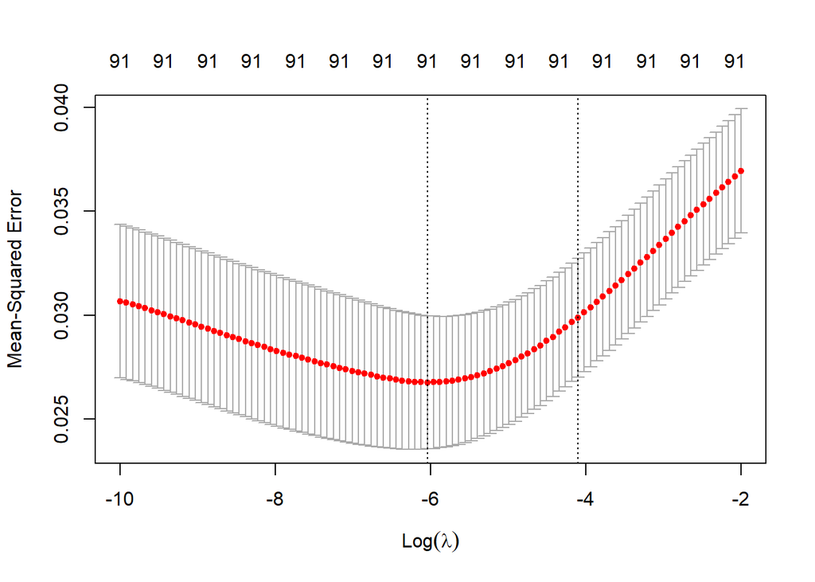

```r
myridge.lambda.seq1 = exp(seq(-10, -2, length.out = 100))
cv.out = cv.glmnet(X[-test.id, ], Y[-test.id], alpha = 0,
                   lambda = myridge.lambda.seq1)
plot(cv.out)
```

```r
which.min(cv.out$lambda > cv.out$lambda.min) == length(cv.out$lambda)
```

```
## [1] FALSE
```

```r
my_ridge = function(X_train, y_train, X_test, y_test, lambda.seq) {
  # stick to the same lambda sequence for the rest of experiments.
  cv.out = cv.glmnet(X_train, y_train, alpha = 0, lambda = lambda.seq)
  Ytest.pred = predict(cv.out, s = cv.out$lambda.min, newx = X_test)
  MSPE.min = mean((y_test - Ytest.pred)^2)

  Ytest.pred = predict(cv.out, s = cv.out$lambda.1se, newx = X_test)
  MSPE.1se = mean((y_test - Ytest.pred)^2)

  list(MSPE.min = MSPE.min, MSPE.1se = MSPE.1se)
}

MSPEs_ridge = my_ridge(
  X_train = X[-test.id, ], y_train = Y[-test.id],
  X_test = X[test.id, ], y_test = Y[test.id],
  lambda.seq = myridge.lambda.seq1)
(MSPE[2] = MSPEs_ridge$MSPE.min)
```

```
## [1] 0.02594114
```

```r
(MSPE[3] = MSPEs_ridge$MSPE.1se)
```

```
## [1] 0.0291112
```

In your submission, **choose your lambda sequence based on one or two traing-and-test splits, and then stick to that sequence for all 50 iterations.**

### Lasso

The CV plot indicates that the default lambda sequence for Lasso seems fine. I will stick to the default lambda sequence through out the experiments.

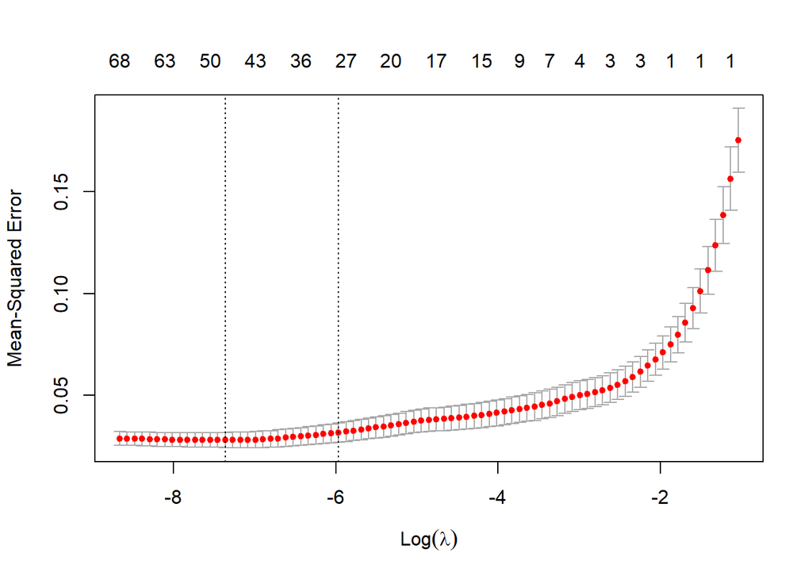

```r
cv.out = cv.glmnet(X[-test.id, ], Y[-test.id], alpha = 1)
plot(cv.out)
```

Lasso with lambda.min, lambda.1se, and Refit

```r
my_lasso = function(X_train, y_train, X_test, y_test) {
  cv.out = cv.glmnet(X_train, y_train, alpha = 1)
  Ytest.pred = predict(cv.out, s = cv.out$lambda.min, newx = X_test)
  MSPE.min = mean((y_test - Ytest.pred)^2)

  Ytest.pred = predict(cv.out, s = cv.out$lambda.1se, newx = X_test)
  MSPE.1se = mean((y_test - Ytest.pred)^2)

  mylasso.coef = predict(cv.out, s = cv.out$lambda.1se, type = "coefficients")
  var.sel = row.names(mylasso.coef)[which(mylasso.coef != 0)[-1]]
  train_data = as.data.frame(cbind(Y=y_train, X_train[, c(var.sel)]))
  mylasso.refit = lm(Y ~ ., train_data)
  Ytest.pred = predict(mylasso.refit, newdata = as.data.frame(X_test))
  MSPE.refit = mean((Ytest.pred - y_test)^2)
  list(MSPE.min = MSPE.min, MSPE.1se = MSPE.1se, MSPE.refit = MSPE.refit)
}

MSPEs_lasso = my_lasso(
  X_train = X[-test.id, ], y_train = Y[-test.id],
  X_test = X[test.id, ], y_test = Y[test.id]
)
(MSPE[4] = MSPEs_lasso$MSPE.min)
```

```
## [1] 0.02697189
```

```r
(MSPE[5] = MSPEs_lasso$MSPE.1se)
```

```
## [1] 0.0311886
```

```r
(MSPE[6] = MSPEs_lasso$MSPE.refit)
```

```
## [1] 0.03133542
```

### PCR

The principle components regression command, `pcr`, returns both the CV errors and the adjusted CV errors. For the definition of adjusted CV used in `pcr`, check Sec 2.4 of [this paper](https://mevik.net/work/publications/MSEP_estimates.pdf).

```r
pcr_fit = pcr(Y ~ ., data= bostonData2[-test.id, ], validation="CV")
CVerr = RMSEP(pcr_fit)$val[1, , ]
best.ncomp = which.min(CVerr) - 1
best.ncomp
```

```
## 58 comps
##       58
```

```r
my_pcr = function(data_train, data_test) {
  pcr_fit = pcr(Y ~ ., data= data_train, validation="CV")
  CVerr = RMSEP(pcr_fit)$val[1, , ]
  adjCVerr = RMSEP(pcr_fit)$val[2, , ]
  best.ncomp = which.min(CVerr) - 1

  if (best.ncomp==0) {
    Ytest.pred = mean(data_train$Y)
  } else {
    Ytest.pred = predict(pcr_fit, data_test, ncomp=best.ncomp)
  }
  mean((Ytest.pred - data_test$Y)^2)
}

MSPE[7] = my_pcr(data_train = bostonData2[-test.id, ], data_test = bostonData2[test.id,])
```

Note that we have to subtract one from `which.min(CVerr)` since the 1st column of the CV table corresponds to the CV error with zero components (i.e., the model with just the intercept) and the k-th column of the CV table corresponds to (k-1) components.

The prediction function does not seem to work when `best.ncomp = 0`. So we have to handle that case separately.

```r
MSPE
```

```
##       Full      R_min      R_1se      L_min      L_1se    L_Refit        PCR
## 0.02614004 0.02594114 0.02911120 0.02697189 0.03118860 0.03133542 0.02267923
```

## Simulation

The function `one_sim` is defined to run a single simulation and the utility method `run_sims` is defined to run multiple simulations. The simulation result of both methods are returned in the form of R data.frame. In each simulation, we randomly split the data into two parts, 75% for training and 25% for testing.

```r
one_sim = function(data_train, data_test, ridge.lambda.seq, full_model_enabled) {
  X_train = data.matrix(data_train[,-1])
  y_train = data_train[,1]
  X_test = data.matrix(data_test[,-1])
  y_test = data_test[,1]

  if (full_model_enabled) {
    MSPE.full = full_model(data_train = data_train, data_test = data_test)
  }

  MSPEs_ridge = my_ridge(
    X_train = X_train, y_train = y_train,
    X_test = X_test, y_test = y_test,
    lambda.seq = ridge.lambda.seq)
  MSPE.ridge.min = MSPEs_ridge$MSPE.min
  MSPE.ridge.1se = MSPEs_ridge$MSPE.1se

  MSPEs_lasso = my_lasso(
    X_train = X_train, y_train = y_train,
    X_test = X_test, y_test = y_test)
  MSPE.lasso.min = MSPEs_lasso$MSPE.min
  MSPE.lasso.1se = MSPEs_lasso$MSPE.1se
  MSPE.l.refit = MSPEs_lasso$MSPE.refit

  MSPE.pcr = my_pcr(data_train = data_train, data_test = data_test)
  result = data.frame(
    Model = c("R_min",        "R_1se",        "L_min",       "L_1se",         "L_Refit",    "PCR"),
    MSPE =  c(MSPE.ridge.min, MSPE.ridge.1se, MSPE.lasso.min, MSPE.lasso.1se, MSPE.l.refit, MSPE.pcr),
    stringsAsFactors = TRUE
  )
  if (full_model_enabled) {
    rbind(
      data.frame(Model = c("Full"), MSPE = MSPE.full, stringsAsFactors = TRUE),
      result)
  } else {
    result
  }
}

run_sims = function(data, runs, ridge.lambda.seq, full_model_enabled) {
  run_sim = function() {
    # data = bostonData2
    # full_model_enabled = TRUE
    n = dim(data)[1]
    ntest = round(n * 0.25)
    test.id = sample(1:n, ntest)
    one_sim(
      data_train = data[-test.id, ],
      data_test = data[test.id, ],
      ridge.lambda.seq = ridge.lambda.seq,
      full_model_enabled = full_model_enabled)
  }

  # data = bostonData2
  # runs=3
  # full_model_enabled = TRUE
  result = replicate(n = runs, expr = run_sim(), simplify = FALSE)
  combined_result = do.call(rbind, result)
  colnames(combined_result) = c("Model", "MSPE")
  combined_result
}
```

We will repeat the following simulation 50 times.

```r
result_bd2 = run_sims(
  data = bostonData2, runs = 50,
  ridge.lambda.seq = myridge.lambda.seq1, full_model_enabled = TRUE)
head(result_bd2)
```

|  | Model | MSPE |
| --- | --- | --- |
| 1 | Full | 0.04536546 |
| 2 | R_min | 0.02820096 |
| 3 | R_1se | 0.02917313 |
| 4 | L_min | 0.02777219 |
| 5 | L_1se | 0.03388614 |
| 6 | L_Refit | 0.03347310 |

```r
dim(result_bd2)
```

```
## [1] 350   2
```

```r
result_bd2$Model = factor(
  result_bd2$Model,
  levels=c("R_min", "R_1se", "L_min", "L_1se", "L_Refit", "PCR", "Full"))
```

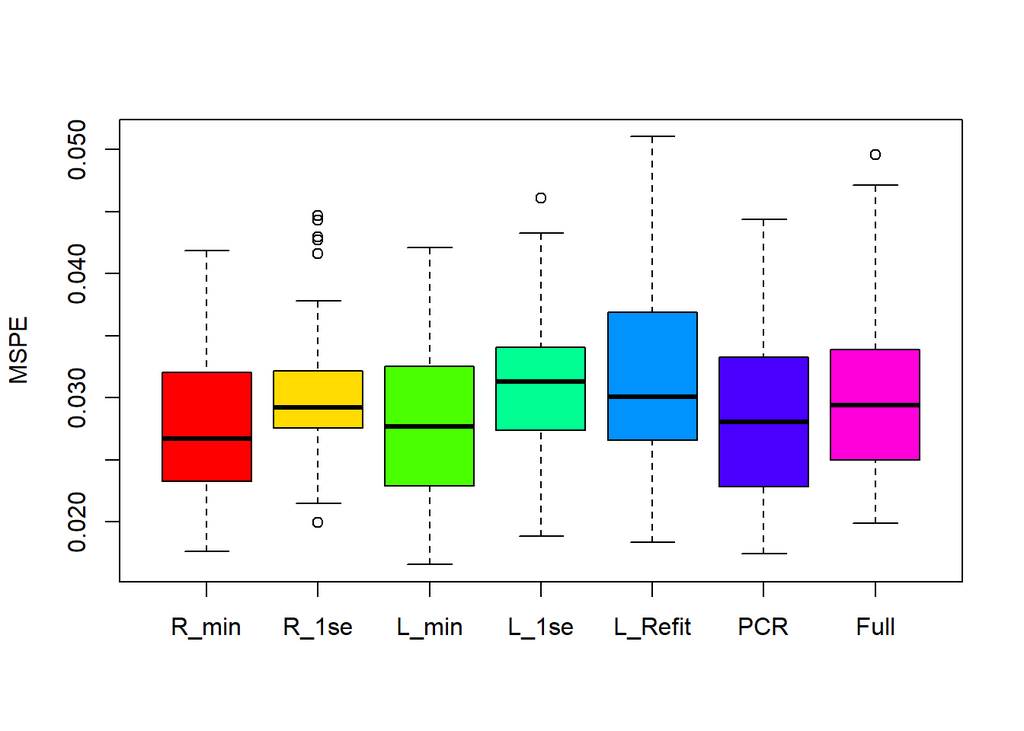

```r
boxplot(MSPE ~ Model, data = as.data.frame(result_bd2), col = rainbow(7), xlab="")
```

`R_min` stands for Ridge with lambda.min model and `R_1se` is for Ridge with lambda.1se model. `L_min`, `L_1se` and `L_Refit` stand for Lasso with lambda.min model, Lasso with lambda.1se and the refit linear addictive model with coefficients from `L_1se` model respectively. `PCR` is for principal component regression model.

From the plot, we can see that Lasso `L_min` model performs slightly better than Lasso `L_1se`. This is normally the case, as `L_1se` is the simpler model chosen in one standard deviation of CV error. Similarly, Ridge `R_min` model performs slightly better than Ridge `R_1se` model. The refit linear addictive model `L_1se` performs slightly better than Lasso `L_1se`, which is normally the case as refit model will utilize the full capacity of predictors. PCR model has similar performance as Lasso `L_min` and Ridge `R_min` models. As the dataset does not contain much noise, the top k principal components `PCR` picked capture the signal well. The full model `Full` also perform fine in the given dataset.

# Simulation for `BostonData3.csv`

## Data Preparation

In `BostonData3.csv` dataset, the first 92 columns are the same as `BostonData2.csv`, and the remaining 500 columns are artificially generated noise features.

```r
bostonData3 = read.csv("BostonData3.csv")
```

```r
head(bostonData3)
```

|  | X | Y | crim | zn | indus | chas | nox | rm | age | dis | rad | tax | ptratio | black | lstat | crim_2 | zn_2 | indus_2 | nox_2 | rm_2 | age_2 | dis_2 | rad_2 | tax_2 | ptratio_2 | black_2 | lstat_2 | crim.zn | crim.indus | … |
| --- | --- | --- | --- | --- | --- | --- | --- | --- | --- | --- | --- | --- | --- | --- | --- | --- | --- | --- | --- | --- | --- | --- | --- | --- | --- | --- | --- | --- | --- | --- |
| 1 | 1 | 3.178054 | -5.064036 | 1.8 | 0.8372475 | 0 | -0.6198967 | 1.883275 | 3.432567 | 1.408545 | 0.0000000 | 5.690359 | 0.4548647 | 3.9690 | 2.231591 | 25.644461 | 3.24 | 0.7009834 | 0.3842719 | 3.546723 | 11.782514 | 1.983999 | 0.000000 | 32.38019 | 0.2069019 | 15.75296 | 4.98 | -9.115265 | -4.239852 | … |
| 2 | 2 | 3.072693 | -3.600502 | 0.0 | 1.9558605 | 0 | -0.7571525 | 1.859574 | 5.529585 | 1.602836 | 0.6931472 | 5.488938 | 1.2364504 | 3.9690 | 3.023243 | 12.963617 | 0.00 | 3.8253902 | 0.5732799 | 3.458015 | 30.576306 | 2.569084 | 0.480453 | 30.12844 | 1.5288097 | 15.75296 | 9.14 | 0.000000 | -7.042080 | … |
| 3 | 3 | 3.546740 | -3.601235 | 0.0 | 1.9558605 | 0 | -0.7571525 | 1.971996 | 2.918119 | 1.602836 | 0.6931472 | 5.488938 | 1.2364504 | 3.9283 | 2.007486 | 12.968893 | 0.00 | 3.8253902 | 0.5732799 | 3.888766 | 8.515420 | 2.569084 | 0.480453 | 30.12844 | 1.5288097 | 15.43154 | 4.03 | 0.000000 | -7.043513 | … |
| 4 | 4 | 3.508556 | -3.430523 | 0.0 | 0.7793249 | 0 | -0.7808861 | 1.945624 | 1.419592 | 1.802073 | 1.0986123 | 5.402677 | 1.7722408 | 3.9463 | 1.714643 | 11.768490 | 0.00 | 0.6073473 | 0.6097831 | 3.785454 | 2.015243 | 3.247466 | 1.206949 | 29.18892 | 3.1408374 | 15.57328 | 2.94 | 0.000000 | -2.673492 | … |
| 5 | 5 | 3.589059 | -2.672924 | 0.0 | 0.7793249 | 0 | -0.7808861 | 1.966693 | 2.162710 | 1.802073 | 1.0986123 | 5.402677 | 1.7722408 | 3.9690 | 2.308679 | 7.144525 | 0.00 | 0.6073473 | 0.6097831 | 3.867880 | 4.677313 | 3.247466 | 1.206949 | 29.18892 | 3.1408374 | 15.75296 | 5.33 | 0.000000 | -2.083076 | … |
| 6 | 6 | 3.356897 | -3.511570 | 0.0 | 0.7793249 | 0 | -0.7808861 | 1.860975 | 2.639947 | 1.802073 | 1.0986123 | 5.402677 | 1.7722408 | 3.9412 | 2.282542 | 12.331127 | 0.00 | 0.6073473 | 0.6097831 | 3.463226 | 6.969322 | 3.247466 | 1.206949 | 29.18892 | 3.1408374 | 15.53306 | 5.21 | 0.000000 | -2.736654 | … |

We remove column `X`, as it contains index. Also, we can see that the number of predictor `p` is bigger than sample size. Therefore, we will not fit a **full linear model** in `BostonData3.csv` simulation.

```r
bostonData3 = bostonData3[,-1]
dim(bostonData3)
```

```
## [1] 506 592
```

Some algorithms need the matrix/vector input (instead of a data frame)

```r
X2 = data.matrix(bostonData3[,-1])
Y2 = bostonData3[,1]
```

## Lambdas for Ridge and Lasso

### Ridge

Ridge with lambda.min and lambda.1se. With my experiments, the lambda of the minimum MSE is not falling at the boundary with the lambda sequence `myridge.lambda.seq2`. So through out the experiments for `BostonData3.csv`, I will stick to `myridge.lambda.seq2` for my ridge regression model.

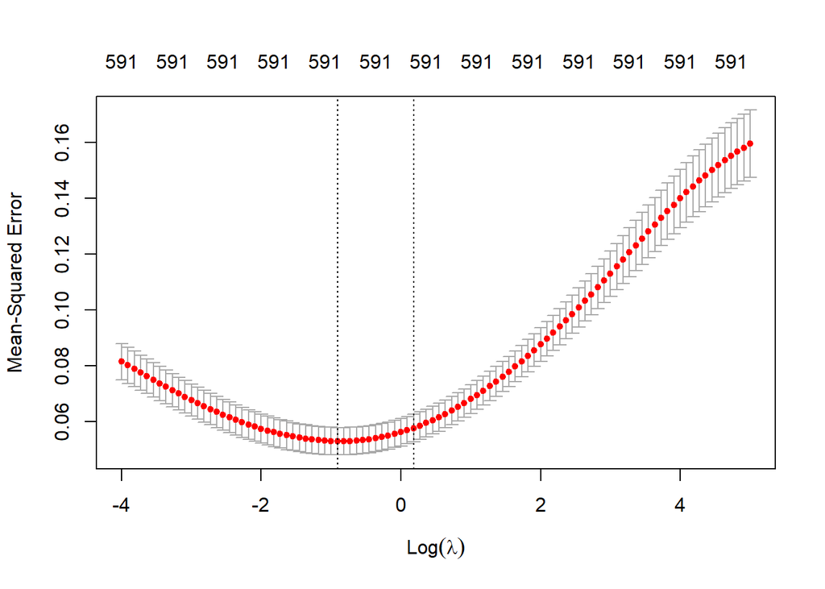

```r
myridge.lambda.seq2 = exp(seq(-4, 5, length.out = 100))
cv.out = cv.glmnet(X2[-test.id, ], Y2[-test.id], alpha = 0,
                   lambda = myridge.lambda.seq2)
plot(cv.out)
```

```r
which.min(cv.out$lambda > cv.out$lambda.min) == length(cv.out$lambda)
```

```
## [1] FALSE
```

### Lasso

The CV plot indicates that the default lambda sequence for Lasso seems fine. I will stick to the default lambda sequence through out the experiments for `BostonData3.csv`.

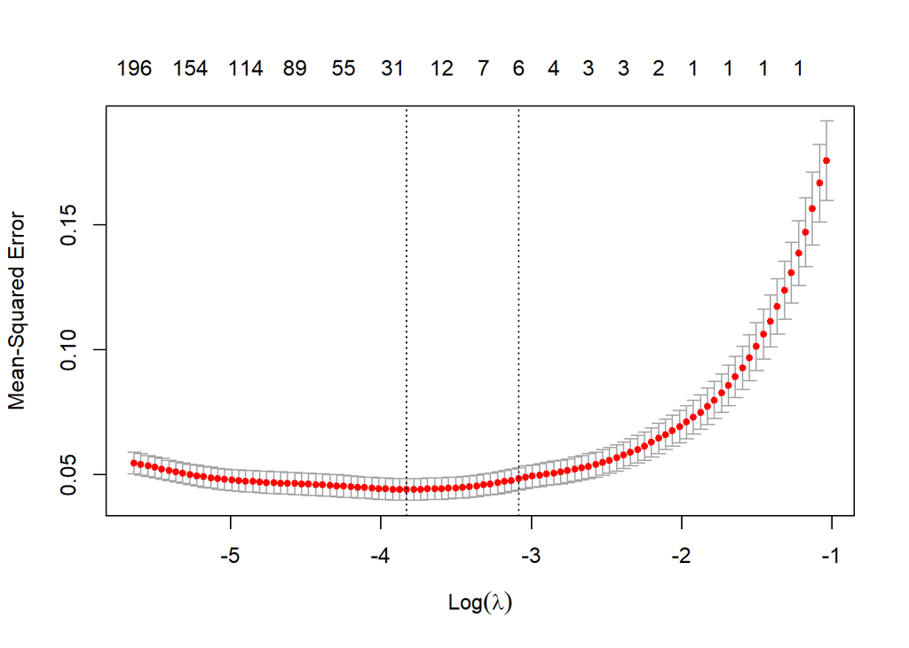

```r
cv.out = cv.glmnet(X2[-test.id, ], Y2[-test.id], alpha = 1)
plot(cv.out)
```

## Simulation

We will repeat the following simulation 50 times.

```r
result_bd3 = run_sims(
  data = bostonData3, runs=50,
  ridge.lambda.seq = myridge.lambda.seq2, full_model_enabled = FALSE)
head(result_bd3)
```

|  | Model | MSPE |
| --- | --- | --- |
| 1 | R_min | 0.04939860 |
| 2 | R_1se | 0.06018170 |
| 3 | L_min | 0.03791279 |
| 4 | L_1se | 0.05051515 |
| 5 | L_Refit | 0.04227131 |
| 6 | PCR | 0.07446639 |

```r
dim(result_bd3)
```

```
## [1] 300   2
```

```r
result_bd3$Model = factor(
  result_bd3$Model,
  levels=c("R_min", "R_1se", "L_min", "L_1se", "L_Refit", "PCR"))
```

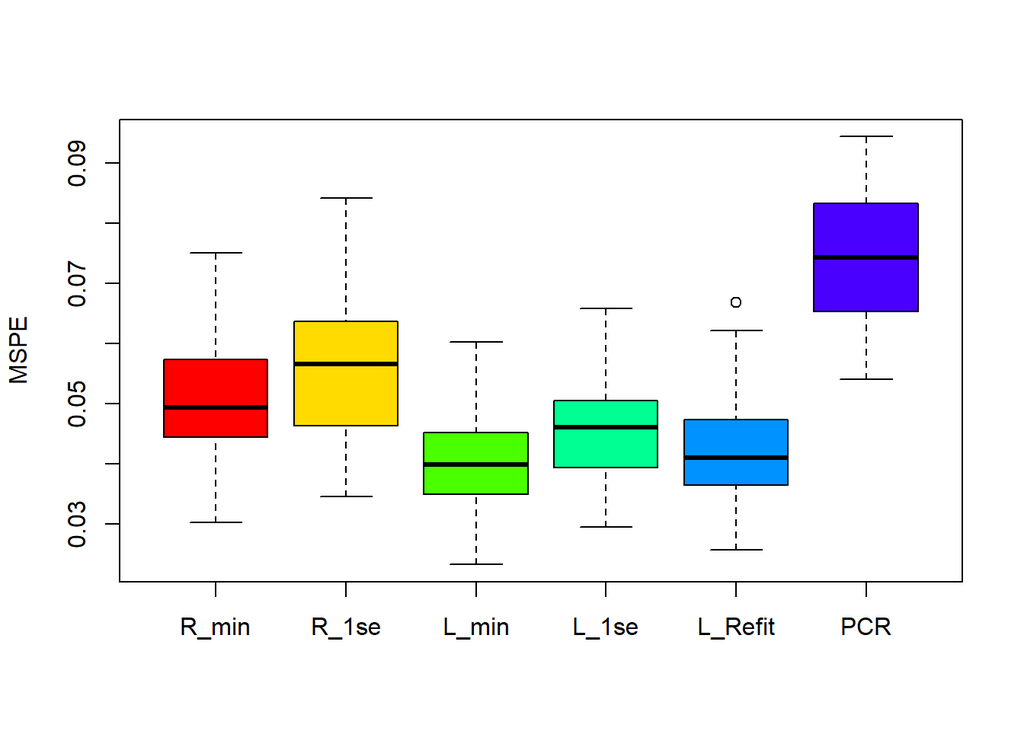

```r
boxplot(MSPE ~ Model, data = as.data.frame(result_bd3), col = rainbow(7), xlab="")
```

`R_min` stands for Ridge with lambda.min model and `R_1se` is for Ridge with lambda.1se model. `L_min`, `L_1se` and `L_Refit` stand for Lasso with lambda.min model, Lasso with lambda.1se and the refit linear addictive model with coefficients from `L_1se` model respectively. `PCR` is for principal component regression model.

From the plot, we can see that Lasso `L_min`, Lasso `L_1se`, and the refit linear addictive model `L_Refit` models performs better than other models. This is expected, as we add lots of noisy predictors into the dataset and Lasso models can eliminate noises(but it may also eliminate week signal predictors). The refit linear model `L_Refit` is doing better than Lasso `L_1se`, which is normally the case as refit model will utilize the full capacity of predictors while Lasso `L_1se` may suppress some week signals. Ridge `R_min` and Ridge `R_1se` don’t perform well in this case. This is because Ridge models don’t eliminate noises and they only shrink these noises more than signal predictors. As the dataset contains lots of noisy predictors, Ridge models contain too many small coefficients fitted to noisy predictors. As a result, Ridge models `R_min` and `R_1se` don’t perform well in this case. `PCR` model perform the worst in this case. This is expected as for each principal component, it is a linear combinations of all predictors. When the dataset contains a lot of noise predictors, these noisy information will be included in the top k principal components through linear combinations. This explains the bad performance of `PCR` model with `BostonData3.csv` dataset.

# Comparing the plots on the two datasets

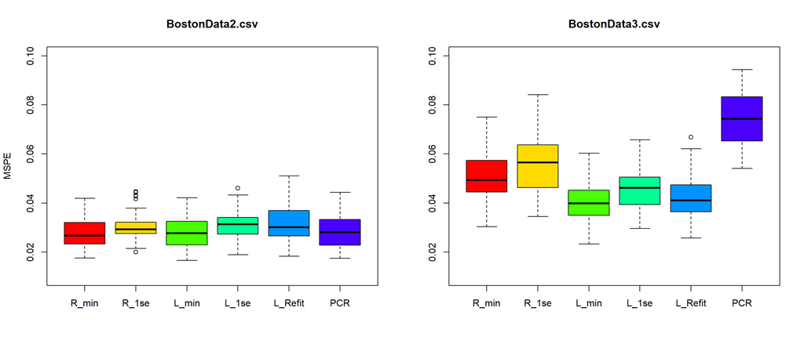

```r
par(mfrow = c(1, 2))
result_bd2_no_full = as.data.frame(result_bd2[result_bd2$Model!="Full",])
result_bd2_no_full = droplevels(result_bd2_no_full)
boxplot(MSPE ~ Model, data = result_bd2_no_full,
        col = rainbow(7), xlab="", main="BostonData2.csv",
        ylim=c(0.01, 0.10))
boxplot(MSPE ~ Model, data = as.data.frame(result_bd3),
        col = rainbow(7), xlab="", ylab="", main="BostonData3.csv",
        ylim=c(0.01, 0.10))
```

**Note** that we don’t fit a **full linear model** in `BostonData3.csv` simulation, as we know that the number of predictor `p` is bigger than sample size. Therefore, we will not fit a full linear model in `BostonData3.csv` simulation and we don’t do comparison for full model.

`R_min` stands for Ridge with lambda.min model and `R_1se` is for Ridge with lambda.1se model. `L_min`, `L_1se` and `L_Refit` stand for Lasso with lambda.min model, Lasso with lambda.1se and the refit linear addictive model with coefficients from `L_1se` model respectively. `PCR` is for principal component regression model.

Overall, all models performs worse in `BostonData3.csv` than in `BostonData2.csv`. But out of them, Lasso models `L_min`, `L_1se` and the linear refit `L_Refit` model performs better than other models in noisy dataset `BostonData3.csv`. This is expected, as Lasso models can eliminate noises. However, while they are trying to eliminate noises, they may also kills week signal predictors. That is why Lasso models performs slightly worse in `BostonData3.csv`(MSPEs are above 0.04) than the ones in `BostonData2.csv`(MSPEs are around 0.03). For both dataset, the refit linear models `L_Refit` are doing better than Lasso `L_1se`, which is normally the case as refit model will utilize the full capacity of predictors while Lasso `L_1se` may suppress some week signals. Additionally, we can see the two Ridge models, `R_min` and `R_1se` perform much worse with noisy dataset `BostonData3.csv` than the ones in `BostonData2.csv`. This is expected, as Ridge models don’t eliminate noises but they only shrink these noises more than signal predictors. `BostonData3.csv` contains a large number of noisy predictors, Ridge models contain too many small coefficients fitted to these noisy predictors. As a results, they perform much worse than the ones in `BostonData2.csv`. Finally, `PCR` model performs well with `BostonData2.csv`, but performs the worst with noisy dataset `BostonData3.csv`. This is expected as each principal component is a linear combinations of all predictors. When the dataset contains a lot of noise predictors, these noisy information will be included in the top k principal components through linear combinations. Whereas, in `BostonData2.csv`, there is not much noise and the `PCR` model performs very well.